# 2nd Assignment: Network robustness

In the first part, you can use some graphs obtained by using the networx library or the library of your choice.

For each selected graph (max 2 or 3) you can perform different types of attack: turn off nodes at random, turn off the highest degree nodes, those with the highest pagerank, those with the highest clustering coefficient, ...

After each removal, compute new measures, for example the size of the giant component or the diameter of the network and then plot these measures with respect to node failures.

Be careful, some of the networkx functions you will use work only for undirected, connected graphs and therefore you need to instrument your code to work on the entire graph first, and on the several components after the split of the original graph into smaller clusters.

Come per la prima esercitazione abbiamo creato un notebook con cui verranno analizzate le varie situazioni.

L'esecuzione del notebook può risultare lenta perché ogni volta che viene rimosso un nodo vengono ricalcolate le varie statistiche come il nodo con maggior degree. Questo perché tenere una "classifica" a priori potrebbe portare a risultati errati.

## Parte 1: random graph

In questa sezione andiamo ad analizzare un Erdös–Rényi random graph generato tramite networkx

Utilizziamo un p relativamente grande: 0,02 per avere una giant component che comprenda almeno il 75% dei nodi.  
Per quanto riguarda il numero di nodi ci siamo fermati a 150 per prestazioni di calcolo e per visualizzare il grafo in questo notebook.

```python
import networkx
graph = networkx.gnp_random_graph(150, 0.02, seed=42)
```

```python
# Import functions
import random
import operator

random.seed(42)

def get_highest_degree_node(G):
    return sorted(G.degree, key=lambda x: x[1], reverse=True)[0][0]

def get_random_node(G):
    list_of_nodes = G.nodes()
    return random.sample(list_of_nodes, 1)[0]

def get_highest_closeness_node(G):
    return sorted(networkx.closeness_centrality(G).items(), key=operator.itemgetter(1),reverse=True)[0][0]

def get_highest_betwennes_node(G):
    return sorted(networkx.betweenness_centrality(G).items(), key=operator.itemgetter(1),reverse=True)[0][0]

def get_highest_clustering_node(G):
    return sorted(networkx.clustering(G).items(), key=operator.itemgetter(1),reverse=True)[0][0]

def connected_component_subgraphs(G):
    for c in networkx.connected_components(G):
        yield G.subgraph(c)
def get_giant_component_size(G):
    return len(sorted(connected_component_subgraphs(G), key=len, reverse=True)[0])
```

```python
# Analyze relative giant component size (relative to the starting graph size)

# Saving inital graph' size
n_nodes = len(graph)

# Creating list variable to iterate
graphs = []
sizes = []
functions = []

# One graph copy and one array of data for each tecnique
random_graph = graph.__class__(graph)
random_giant_sizes = []
graphs.append(random_graph)
sizes.append(random_giant_sizes)
functions.append(get_random_node)

degree_graph = graph.__class__(graph)
degree_giant_sizes = []
graphs.append(degree_graph)
sizes.append(degree_giant_sizes)
functions.append(get_highest_degree_node)

closeness_graph = graph.__class__(graph)
closeness_giant_sizes = []
graphs.append(closeness_graph)
sizes.append(closeness_giant_sizes)
functions.append(get_highest_closeness_node)

betweenness_graph = graph.__class__(graph)
betweenness_giant_sizes = []
graphs.append(betweenness_graph)
sizes.append(betweenness_giant_sizes)
functions.append(get_highest_betwennes_node)


clustering_graph = graph.__class__(graph)
clustering_giant_sizes = []
graphs.append(clustering_graph)
sizes.append(clustering_giant_sizes)
functions.append(get_highest_clustering_node)


for i in range(len(graphs)):
        sizes[i].append(get_giant_component_size(graphs[i]) / n_nodes)

for _ in range(len(graph) - 1):
    # Per ogni tipo di attacco
    for i in range(len(graphs)):
        node_to_remove = functions[i](graphs[i])
        graphs[i].remove_node(node_to_remove)
        sizes[i].append(get_giant_component_size(graphs[i]) / n_nodes)
```

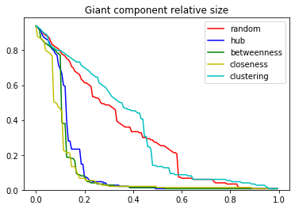

```python
# Plotting size results
import matplotlib.pyplot as plt
import numpy as np

x = np.arange(0, 1, 1.0/len(graph))

legends = ["random", "hub", "betweenness", "closeness", "clustering"]
colors = ['r', 'b', 'g', 'y', 'c', 'm', 'k']

for i in range(len(sizes)):
    plt.plot(x, sizes[i], colors[i], label=legends[i])

plt.title("Giant component relative size")
plt.ylim(ymin=0)
plt.legend()
plt.show()
```

```python
# Analyze diameter
def get_diameter(G):
    components = sorted(connected_component_subgraphs(G), key=len, reverse=True)
    # Come visto da slide ha senso se <k> > 1
    nnodes = G.number_of_nodes()
    deg = sum(d for n, d in G.degree()) / float(nnodes)
    if deg < 1:
        return False
    return networkx.diameter(components[0])

# Creating list variable to iterate
graphs = []
diameters = []
functions = []

# One graph copy and one array of data for each tecnique
random_graph = graph.__class__(graph)
random_giant_diameters = []
graphs.append(random_graph)
diameters.append(random_giant_diameters)
functions.append(get_random_node)

degree_graph = graph.__class__(graph)
degree_giant_diameters = []
graphs.append(degree_graph)
diameters.append(degree_giant_diameters)
functions.append(get_highest_degree_node)

closeness_graph = graph.__class__(graph)
closeness_giant_diameters = []
graphs.append(closeness_graph)
diameters.append(closeness_giant_diameters)
functions.append(get_highest_closeness_node)

betweenness_graph = graph.__class__(graph)
betweenness_giant_diameters = []
graphs.append(betweenness_graph)
diameters.append(betweenness_giant_diameters)
functions.append(get_highest_betwennes_node)


clustering_graph = graph.__class__(graph)
clustering_giant_diameters = []
graphs.append(clustering_graph)
diameters.append(clustering_giant_diameters)
functions.append(get_highest_clustering_node)

# A causa della complessita computazione del calcolo del diametro non possiamo provarlo troppe volte, calcolo solo 3 volte
# Il diametro è in percentuale al numero di nodi: 100%: devo attraversare tutti i nodi , 1% devo attraversare l'1% dei nodi per raggiungere ogni altro nodo del giant component

initial_diameter = get_diameter(graphs[i]) / get_giant_component_size(graphs[i])

for i in range(len(graphs)):
        diameters[i].append(initial_diameter)

# Lo limito a 25 nodi (31 perché l'ultima computazione non viene considerata)
for j in range(31):
    # Per ogni tipo di attacco
    end = False
    for i in range(len(graphs)):
        node_to_remove = functions[i](graphs[i])
        graphs[i].remove_node(node_to_remove)
        # Qui decido quando computare il diametro
        if (j + 1) % 5 == 0:
            diameter = get_diameter(graphs[i])
            if diameter != False:
                diameters[i].append(diameter / get_giant_component_size(graphs[i]))
            else:
                # Se è inutile calcolare il diametro termino
                diameters[i].append(1)
                end = True
    if end:
        break
```

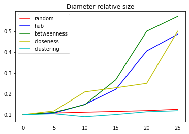

```python
# Plotting diameter results

x = [0, 5, 10, 15, 20, 25]

legends = ["random", "hub", "betweenness", "closeness", "clustering"]
colors = ['r', 'b', 'g', 'y', 'c', 'm', 'k']

for i in range(len(diameters)):
    # Rimuovo dai diametri l'ultimo elemento perché non ha valore
    plt.plot(x, diameters[i][:-1], colors[i], label=legends[i])

plt.title("Diameter relative size")
plt.legend()
plt.show()
```

### Considerazioni

Per quanto riguarda la size della giant component i dati sono conformi a quanto ci aspettavamo, anche gli attacchi a nodi random hanno il loro effetto.

## Parte 2: Small world graph

In questa sezione andiamo ad analizzare un Watts-Strogatz small-world graph generato tramite networkx.

Il numero di nodi è uguale al grafo precedente, la sua p è uguale a 0.07, un valore che permette di dare risalto ai cossiddetti cluster di nodi

```python
import networkx
graph = networkx.watts_strogatz_graph(150,4,0.07, seed=42)
```

```python
# Import functions
import random
import operator

random.seed(42)

def get_highest_degree_node(G):
    return sorted(G.degree, key=lambda x: x[1], reverse=True)[0][0]

def get_random_node(G):
    list_of_nodes = G.nodes()
    return random.sample(list_of_nodes, 1)[0]

def get_highest_closeness_node(G):
    return sorted(networkx.closeness_centrality(G).items(), key=operator.itemgetter(1),reverse=True)[0][0]

def get_highest_betwennes_node(G):
    return sorted(networkx.betweenness_centrality(G).items(), key=operator.itemgetter(1),reverse=True)[0][0]

def get_highest_clustering_node(G):
    return sorted(networkx.clustering(G).items(), key=operator.itemgetter(1),reverse=True)[0][0]

def connected_component_subgraphs(G):
    for c in networkx.connected_components(G):
        yield G.subgraph(c)
def get_giant_component_size(G):
    return len(sorted(connected_component_subgraphs(G), key=len, reverse=True)[0])
```

```python
# Analyze relative giant component size (relative to the starting graph size)

# Saving inital graph' size
n_nodes = len(graph)

# Creating list variable to iterate
graphs = []
sizes = []
functions = []

# One graph copy and one array of data for each tecnique
random_graph = graph.__class__(graph)
random_giant_sizes = []
graphs.append(random_graph)
sizes.append(random_giant_sizes)
functions.append(get_random_node)

degree_graph = graph.__class__(graph)
degree_giant_sizes = []
graphs.append(degree_graph)
sizes.append(degree_giant_sizes)
functions.append(get_highest_degree_node)

closeness_graph = graph.__class__(graph)
closeness_giant_sizes = []
graphs.append(closeness_graph)
sizes.append(closeness_giant_sizes)
functions.append(get_highest_closeness_node)

betweenness_graph = graph.__class__(graph)
betweenness_giant_sizes = []
graphs.append(betweenness_graph)
sizes.append(betweenness_giant_sizes)
functions.append(get_highest_betwennes_node)


clustering_graph = graph.__class__(graph)
clustering_giant_sizes = []
graphs.append(clustering_graph)
sizes.append(clustering_giant_sizes)
functions.append(get_highest_clustering_node)


for i in range(len(graphs)):
        sizes[i].append(get_giant_component_size(graphs[i]) / n_nodes)

for _ in range(len(graph) - 1):
    # Per ogni tipo di attacco
    for i in range(len(graphs)):
        node_to_remove = functions[i](graphs[i])
        graphs[i].remove_node(node_to_remove)
        sizes[i].append(get_giant_component_size(graphs[i]) / n_nodes)
```

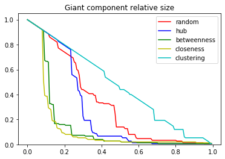

```python
# Plotting size results
import matplotlib.pyplot as plt
import numpy as np

x = np.arange(0, 1, 1.0/len(graph))

legends = ["random", "hub", "betweenness", "closeness", "clustering"]
colors = ['r', 'b', 'g', 'y', 'c', 'm', 'k']

for i in range(len(sizes)):
    plt.plot(x, sizes[i], colors[i], label=legends[i])

plt.title("Giant component relative size")
plt.ylim(ymin=0)
plt.legend()
plt.show()
```

```python
# Analyze diameter
def get_diameter(G):
    components = sorted(connected_component_subgraphs(G), key=len, reverse=True)
    # Come visto da slide ha senso se <k> > 1
    nnodes = G.number_of_nodes()
    deg = sum(d for n, d in G.degree()) / float(nnodes)
    if deg < 1:
        return False
    return networkx.diameter(components[0])

# Creating list variable to iterate
graphs = []
diameters = []
functions = []

# One graph copy and one array of data for each tecnique
random_graph = graph.__class__(graph)
random_giant_diameters = []
graphs.append(random_graph)
diameters.append(random_giant_diameters)
functions.append(get_random_node)

degree_graph = graph.__class__(graph)
degree_giant_diameters = []
graphs.append(degree_graph)
diameters.append(degree_giant_diameters)
functions.append(get_highest_degree_node)

closeness_graph = graph.__class__(graph)
closeness_giant_diameters = []
graphs.append(closeness_graph)
diameters.append(closeness_giant_diameters)
functions.append(get_highest_closeness_node)

betweenness_graph = graph.__class__(graph)
betweenness_giant_diameters = []
graphs.append(betweenness_graph)
diameters.append(betweenness_giant_diameters)
functions.append(get_highest_betwennes_node)


clustering_graph = graph.__class__(graph)
clustering_giant_diameters = []
graphs.append(clustering_graph)
diameters.append(clustering_giant_diameters)
functions.append(get_highest_clustering_node)

# A causa della complessita computazione del calcolo del diametro non possiamo provarlo troppe volte, calcolo solo 3 volte
# Il diametro è in percentuale al numero di nodi: 100%: devo attraversare tutti i nodi , 1% devo attraversare l'1% dei nodi per raggiungere ogni altro nodo del giant component

initial_diameter = get_diameter(graphs[i]) / get_giant_component_size(graphs[i])

for i in range(len(graphs)):
        diameters[i].append(initial_diameter)

# Lo limito a 25 nodi (31 perché l'ultima computazione non viene considerata)
for j in range(31):
    # Per ogni tipo di attacco
    end = False
    for i in range(len(graphs)):
        node_to_remove = functions[i](graphs[i])
        graphs[i].remove_node(node_to_remove)
        # Qui decido quando computare il diametro
        if (j + 1) % 5 == 0:
            diameter = get_diameter(graphs[i])
            if diameter != False:
                diameters[i].append(diameter / get_giant_component_size(graphs[i]))
            else:
                # Se è inutile calcolare il diametro termino
                diameters[i].append(1)
                end = True
    if end:
        break
```

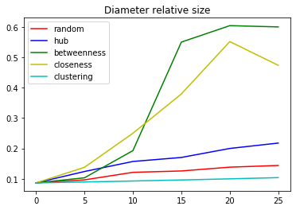

```python
# Plotting diameter results

x = [0, 5, 10, 15, 20, 25]

legends = ["random", "hub", "betweenness", "closeness", "clustering"]
colors = ['r', 'b', 'g', 'y', 'c', 'm', 'k']

for i in range(len(diameters)):
    # Rimuovo dai diametri l'ultimo elemento perché non ha valore
    plt.plot(x, diameters[i][:-1], colors[i], label=legends[i])

plt.title("Diameter relative size")
plt.legend()
plt.show()
```

### Considerazioni

Sia per quanto riguarda la dimensione della giant component i dati sono conformi a quanto ci aspettavamo, gli attacchi a nodi random hanno il loro effetto, mentre attacchi a nodi con alto clustering non fanno particolarmente danno proprio per la struttura del cluster.

Come visto dalla teoria levando i nodi con maggiore closeness o betweenness la rete collassa.

## Parte 3: Scale free graph

In questa sezione andiamo ad analizzare una scale free network generato tramite networkx, in particolare attraverso il modello Barabasi-Albert.

Come prima il numero di nodi rimane inviariato, e ciascuno di esso è collegato rispettivamente con due nodi, preferibilmente con alta degree

Ci aspettiamo che la rete sia robusta a failure di nodi random.

```python
import networkx
graph = networkx.barabasi_albert_graph(150,2, seed=42)
```

```python
# Import functions
import random
import operator

random.seed(42)

def get_highest_degree_node(G):
    return sorted(G.degree, key=lambda x: x[1], reverse=True)[0][0]

def get_random_node(G):
    list_of_nodes = G.nodes()
    return random.sample(list_of_nodes, 1)[0]

def get_highest_closeness_node(G):
    return sorted(networkx.closeness_centrality(G).items(), key=operator.itemgetter(1),reverse=True)[0][0]

def get_highest_betwennes_node(G):
    return sorted(networkx.betweenness_centrality(G).items(), key=operator.itemgetter(1),reverse=True)[0][0]

def get_highest_clustering_node(G):
    return sorted(networkx.clustering(G).items(), key=operator.itemgetter(1),reverse=True)[0][0]

def connected_component_subgraphs(G):
    for c in networkx.connected_components(G):
        yield G.subgraph(c)
def get_giant_component_size(G):
    return len(sorted(connected_component_subgraphs(G), key=len, reverse=True)[0])
```

```python
# Analyze relative giant component size (relative to the starting graph size)

# Saving inital graph' size
n_nodes = len(graph)

# Creating list variable to iterate
graphs = []
sizes = []
functions = []

# One graph copy and one array of data for each tecnique
random_graph = graph.__class__(graph)
random_giant_sizes = []
graphs.append(random_graph)
sizes.append(random_giant_sizes)
functions.append(get_random_node)

degree_graph = graph.__class__(graph)
degree_giant_sizes = []
graphs.append(degree_graph)
sizes.append(degree_giant_sizes)
functions.append(get_highest_degree_node)

closeness_graph = graph.__class__(graph)
closeness_giant_sizes = []
graphs.append(closeness_graph)
sizes.append(closeness_giant_sizes)
functions.append(get_highest_closeness_node)

betweenness_graph = graph.__class__(graph)
betweenness_giant_sizes = []
graphs.append(betweenness_graph)
sizes.append(betweenness_giant_sizes)
functions.append(get_highest_betwennes_node)


clustering_graph = graph.__class__(graph)
clustering_giant_sizes = []
graphs.append(clustering_graph)
sizes.append(clustering_giant_sizes)
functions.append(get_highest_clustering_node)


for i in range(len(graphs)):
        sizes[i].append(get_giant_component_size(graphs[i]) / n_nodes)

for _ in range(len(graph) - 1):
    # Per ogni tipo di attacco
    for i in range(len(graphs)):
        node_to_remove = functions[i](graphs[i])
        graphs[i].remove_node(node_to_remove)
        sizes[i].append(get_giant_component_size(graphs[i]) / n_nodes)
```

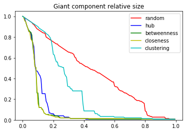

```python
# Plotting size results
import matplotlib.pyplot as plt
import numpy as np

x = np.arange(0, 1, 1.0/len(graph))

legends = ["random", "hub", "betweenness", "closeness", "clustering"]
colors = ['r', 'b', 'g', 'y', 'c', 'm', 'k']

for i in range(len(sizes)):
    plt.plot(x, sizes[i], colors[i], label=legends[i])

plt.title("Giant component relative size")
plt.ylim(ymin=0)
plt.legend()
plt.show()
```

```python
# Analyze diameter
def get_diameter(G):
    components = sorted(connected_component_subgraphs(G), key=len, reverse=True)
    # Come visto da slide ha senso se <k> > 1
    nnodes = G.number_of_nodes()
    deg = sum(d for n, d in G.degree()) / float(nnodes)
    if deg < 1:
        return False
    return networkx.diameter(components[0])

# Creating list variable to iterate
graphs = []
diameters = []
functions = []

# One graph copy and one array of data for each tecnique
random_graph = graph.__class__(graph)
random_giant_diameters = []
graphs.append(random_graph)
diameters.append(random_giant_diameters)
functions.append(get_random_node)

degree_graph = graph.__class__(graph)
degree_giant_diameters = []
graphs.append(degree_graph)
diameters.append(degree_giant_diameters)
functions.append(get_highest_degree_node)

closeness_graph = graph.__class__(graph)
closeness_giant_diameters = []
graphs.append(closeness_graph)
diameters.append(closeness_giant_diameters)
functions.append(get_highest_closeness_node)

betweenness_graph = graph.__class__(graph)
betweenness_giant_diameters = []
graphs.append(betweenness_graph)
diameters.append(betweenness_giant_diameters)
functions.append(get_highest_betwennes_node)


clustering_graph = graph.__class__(graph)
clustering_giant_diameters = []
graphs.append(clustering_graph)
diameters.append(clustering_giant_diameters)
functions.append(get_highest_clustering_node)

# A causa della complessita computazione del calcolo del diametro non possiamo provarlo troppe volte, calcolo solo 3 volte
# Il diametro è in percentuale al numero di nodi: 100%: devo attraversare tutti i nodi , 1% devo attraversare l'1% dei nodi per raggiungere ogni altro nodo del giant component

initial_diameter = get_diameter(graphs[i]) / get_giant_component_size(graphs[i])

for i in range(len(graphs)):
        diameters[i].append(initial_diameter)

# Lo limito a 25 nodi (31 perché l'ultima computazione non viene considerata)
for j in range(31):
    # Per ogni tipo di attacco
    end = False
    for i in range(len(graphs)):
        node_to_remove = functions[i](graphs[i])
        graphs[i].remove_node(node_to_remove)
        # Qui decido quando computare il diametro
        if (j + 1) % 5 == 0:
            diameter = get_diameter(graphs[i])
            if diameter != False:
                diameters[i].append(diameter / get_giant_component_size(graphs[i]))
            else:
                # Se è inutile calcolare il diametro termino
                diameters[i].append(1)
                end = True
    if end:
        break
```

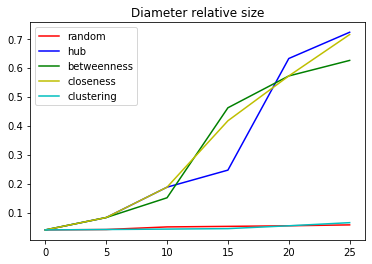

```python
# Plotting diameter results

x = [0, 5, 10, 15, 20, 25]

legends = ["random", "hub", "betweenness", "closeness", "clustering"]
colors = ['r', 'b', 'g', 'y', 'c', 'm', 'k']

for i in range(len(diameters)):
    # Rimuovo dai diametri l'ultimo elemento perché non ha valore
    plt.plot(x, diameters[i][:-1], colors[i], label=legends[i])

plt.title("Diameter relative size")
plt.legend()
plt.show()
```

## Parte 4: DIBRIS graph

In questa sezione andiamo ad analizzare il nostro grafo reale.

Abbiamo visto che il grafo è di tipo smallworld, per cui ci aspettiamo che attacchi nei confronti dei nodi con alta closeness e betweenness abbiano molto effetto, mentre attacchi di tipo clustering non abbiano effetto.

```python
import networkx
graph = networkx.read_adjlist("../graphs/dibris_graph.txt")
```

```python
# Import functions
import random
import operator

random.seed(42)

def get_highest_degree_node(G):
    return sorted(G.degree, key=lambda x: x[1], reverse=True)[0][0]

def get_random_node(G):
    list_of_nodes = G.nodes()
    return random.sample(list_of_nodes, 1)[0]

def get_highest_closeness_node(G):
    return sorted(networkx.closeness_centrality(G).items(), key=operator.itemgetter(1),reverse=True)[0][0]

def get_highest_betwennes_node(G):
    return sorted(networkx.betweenness_centrality(G).items(), key=operator.itemgetter(1),reverse=True)[0][0]

def get_highest_clustering_node(G):
    return sorted(networkx.clustering(G).items(), key=operator.itemgetter(1),reverse=True)[0][0]

def connected_component_subgraphs(G):
    for c in networkx.connected_components(G):
        yield G.subgraph(c)
def get_giant_component_size(G):
    return len(sorted(connected_component_subgraphs(G), key=len, reverse=True)[0])
```

```python
# Analyze relative giant component size (relative to the starting graph size)

# Saving inital graph' size
n_nodes = len(graph)

# Creating list variable to iterate
graphs = []
sizes = []
functions = []

# One graph copy and one array of data for each tecnique
random_graph = graph.__class__(graph)
random_giant_sizes = []
graphs.append(random_graph)
sizes.append(random_giant_sizes)
functions.append(get_random_node)

degree_graph = graph.__class__(graph)
degree_giant_sizes = []
graphs.append(degree_graph)
sizes.append(degree_giant_sizes)
functions.append(get_highest_degree_node)

closeness_graph = graph.__class__(graph)
closeness_giant_sizes = []
graphs.append(closeness_graph)
sizes.append(closeness_giant_sizes)
functions.append(get_highest_closeness_node)

betweenness_graph = graph.__class__(graph)
betweenness_giant_sizes = []
graphs.append(betweenness_graph)
sizes.append(betweenness_giant_sizes)
functions.append(get_highest_betwennes_node)


clustering_graph = graph.__class__(graph)
clustering_giant_sizes = []
graphs.append(clustering_graph)
sizes.append(clustering_giant_sizes)
functions.append(get_highest_clustering_node)


for i in range(len(graphs)):
        sizes[i].append(get_giant_component_size(graphs[i]) / n_nodes)

for _ in range(len(graph) - 1):
    # Per ogni tipo di attacco
    for i in range(len(graphs)):
        node_to_remove = functions[i](graphs[i])
        graphs[i].remove_node(node_to_remove)
        sizes[i].append(get_giant_component_size(graphs[i]) / n_nodes)
```

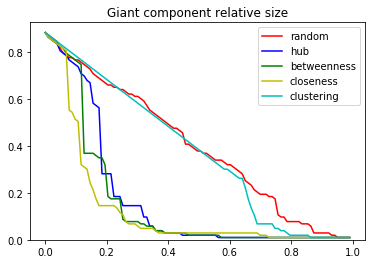

```python
# Plotting size results
import matplotlib.pyplot as plt
import numpy as np

x = np.arange(0, 1, 1.0/len(graph))

legends = ["random", "hub", "betweenness", "closeness", "clustering"]
colors = ['r', 'b', 'g', 'y', 'c', 'm', 'k']

for i in range(len(sizes)):
    plt.plot(x[:-1], sizes[i], colors[i], label=legends[i])

plt.title("Giant component relative size")
plt.ylim(ymin=0)
plt.legend()
plt.show()
```

```python
# Analyze diameter
def get_diameter(G):
    components = sorted(connected_component_subgraphs(G), key=len, reverse=True)
    # Come visto da slide ha senso se <k> > 1
    nnodes = G.number_of_nodes()
    deg = sum(d for n, d in G.degree()) / float(nnodes)
    if deg < 1:
        return False
    return networkx.diameter(components[0])

# Creating list variable to iterate
graphs = []
diameters = []
functions = []

# One graph copy and one array of data for each tecnique
random_graph = graph.__class__(graph)
random_giant_diameters = []
graphs.append(random_graph)
diameters.append(random_giant_diameters)
functions.append(get_random_node)

degree_graph = graph.__class__(graph)
degree_giant_diameters = []
graphs.append(degree_graph)
diameters.append(degree_giant_diameters)
functions.append(get_highest_degree_node)

closeness_graph = graph.__class__(graph)
closeness_giant_diameters = []
graphs.append(closeness_graph)
diameters.append(closeness_giant_diameters)
functions.append(get_highest_closeness_node)

betweenness_graph = graph.__class__(graph)
betweenness_giant_diameters = []
graphs.append(betweenness_graph)
diameters.append(betweenness_giant_diameters)
functions.append(get_highest_betwennes_node)


clustering_graph = graph.__class__(graph)
clustering_giant_diameters = []
graphs.append(clustering_graph)
diameters.append(clustering_giant_diameters)
functions.append(get_highest_clustering_node)

# A causa della complessita computazione del calcolo del diametro non possiamo provarlo troppe volte, calcolo solo 3 volte
# Il diametro è in percentuale al numero di nodi: 100%: devo attraversare tutti i nodi , 1% devo attraversare l'1% dei nodi per raggiungere ogni altro nodo del giant component

initial_diameter = get_diameter(graphs[i]) / get_giant_component_size(graphs[i])

for i in range(len(graphs)):
        diameters[i].append(initial_diameter)

# Lo limito a 25 nodi (31 perché l'ultima computazione non viene considerata)
for j in range(31):
    # Per ogni tipo di attacco
    end = False
    for i in range(len(graphs)):
        node_to_remove = functions[i](graphs[i])
        graphs[i].remove_node(node_to_remove)
        # Qui decido quando computare il diametro
        if (j + 1) % 5 == 0:
            diameter = get_diameter(graphs[i])
            if diameter != False:
                diameters[i].append(diameter / get_giant_component_size(graphs[i]))
            else:
                # Se è inutile calcolare il diametro termino
                diameters[i].append(1)
                end = True
    if end:
        break
```

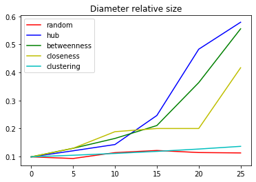

```python
# Plotting diameter results

x = [0, 5, 10, 15, 20 ,25]

legends = ["random", "hub", "betweenness", "closeness", "clustering"]
colors = ['r', 'b', 'g', 'y', 'c', 'm', 'k']

for i in range(len(diameters)):
    # Rimuovo dai diametri l'ultimo elemento perché non ha valore
    plt.plot(x, diameters[i][:-1], colors[i], label=legends[i])

plt.title("Diameter relative size")
plt.legend()
plt.show()
```

### Considerazioni

Sia per quanto riguarda la dimensione della giant component i dati sono conformi a quanto ci aspettavamo quasi nella totalità delle tipologie. In la dimensione della giant size dimostra che il grafo è molto simile anche una rete di tipo scalefree perché attacchi random non hanno particolare effetto.